# Homework 1

### Exercise 3:

Make a bar plot of `manufacturer`. Flip it so that the manufacturers are on the y-axis. Order the bars by height. Which manufacturer produced the most cars? Which produced the least?

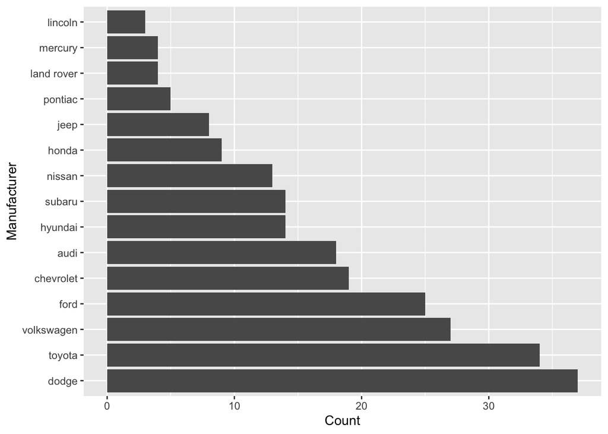

```r
library(forcats)
mpg %>%
ggplot(aes(x=fct_infreq(manufacturer))) +
labs(x='Manufacturer', y='Count') +
coord_flip() +
geom_bar()
```

Dodge produced the most number of cars, and Lincoln produced the least number of cars.

### Exercise 4:

Make a box plot of `hwy`, grouped by `cyl`. Use `geom_jitter()` and the `alpha` argument to add points to the plot.

Describe what you see. Is there a relationship between `hwy` and `cyl`? What do you notice?

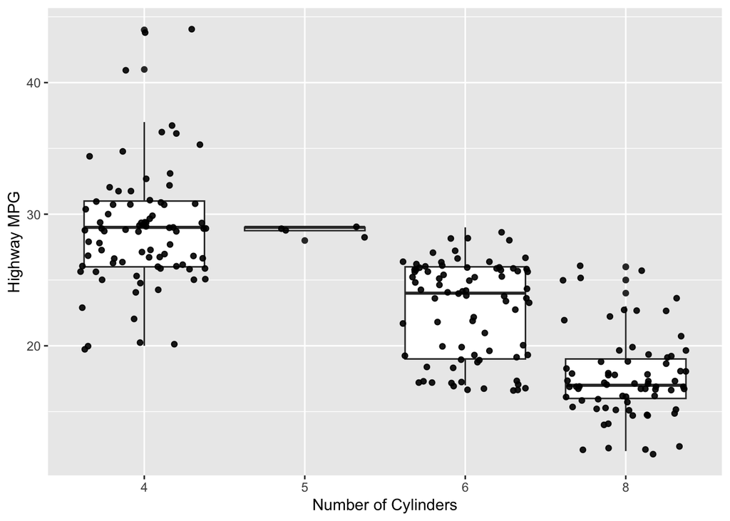

```r
mpg %>%
ggplot(aes(x=factor(cyl), y=hwy)) +
labs(x='Number of Cylinders', y='Highway MPG') +
geom_boxplot() +
geom_jitter(alpha=0.9)
```

### Exercise 5:

Use the `corrplot` package to make a lower triangle correlation matrix of the `mpg` dataset. (Hint: You can find information on the package [here.](https://cran.r-project.org/web/packages/corrplot/vignettes/corrplot-intro.html))

Which variables are positively or negatively correlated with which others? Do these relationships make sense to you? Are there any that surprise you?

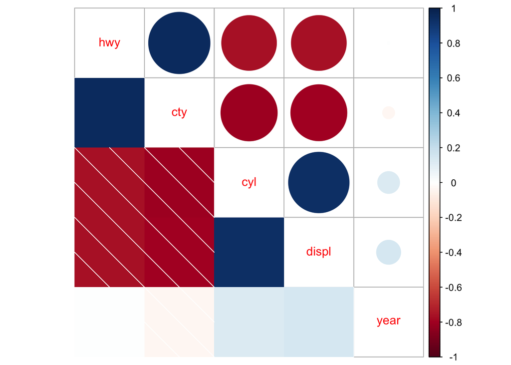

```r
mpg %>%
select(is.numeric) %>%
cor() %>%
corrplot.mixed(order='AOE', lower='shade')
```

As expected, hwy and cty were very positively correlated. This is because the more miles a car is able to drive per gallon on the highway should be positively correlated with the miles a car is able to drive per gallon in the city. In addition, cyl and displ were also very positively correlated. After understanding the variables, this makes sense because the more cylinders a car has, the more engine displacement (in litres), or a higher volume of engine a car would have. The negative correlation between cty and cyl also makes sense because heavier vehicles usually aren’t able to drive as many miles/gallon. Same goes for hwy and cyl. Also there was no correlation between year and highway, which did surprise me a little as I expected a slight positive correlation. This means that cars didn’t really become more efficient from 1999-2008 in terms of more miles driven per gallon.